# Q1

Yi Hung Chen

2022-12-12

## Assignment 1

In this assignment, kernel method is preformed to predict the hourly temperatures for a certian date and place in Sweden. Two data files (stations.csv and temps50k.csv) are given which should be combined according to “station_number”.

There are three different Gaussian kernels that are used in this assignment:

1. The physical distance from a station to the point of interest. For this purpose, use the function distHaversine from the R package geosphere.
2. The distance between the day a temperature measurement was made and the day of interest.
3. The distance between the hour of the day a temperature measurement was made and the hour of interest.

To begin with, the first task is to choose an appropriate smoothing coefficient or width for each of three kernels above. After that combined a kernel by the sum of those three kernels.  
Since no cross-validation should be used so the width are manually chosen to have larger kernel values closer to the target point and vice versa. Below are the plots showing the kernel value as a function of distance. The values are chosen by following reason:

1. Kernel width of physical distance(h_distance=50000), which means 50 km. This is to gives larger kernel value to near by stations(<50km). As Figure 1 shown below, if the data is from any station located more than 100km away from the target location, the data will not affect the prediction much. Note: In Figure 1, only kernel values within 200km are presented. As the true maximum distance to the target station ( 1186.7986499km) is way to far and the kernel value is already small after 100km.

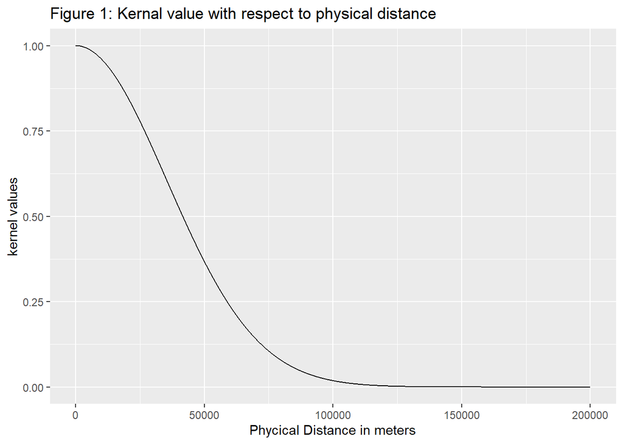

2. Kernel width of date difference(h_date <- 132.5). This is to gives larger kernel value to the observation within same year, especially for the month that is within half a year difference to the target date. As Figure 2 shown below, as the date difference approach 500 days the kernel value become very small. However, this is not ideal in real life scenario, since the same date of different years should have larger impact on prediction than the date in different season. Note: In Figure 2, only kernel values within 1500 days are presented. As the true maximum date difference to the target date ( 2.6363^{4} days) is way to high and the kernel value is already small after 500 days.

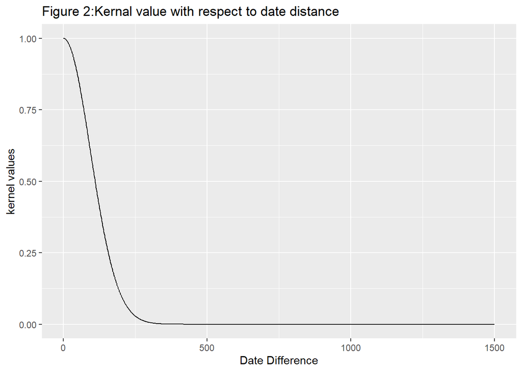

3. Kernel width of hour difference(h_time <- 3), which gives larger kernel value to the observation within 3 hours, and lower kernel value for more than 6 hours difference. This is to account for the difference between day time and night time.

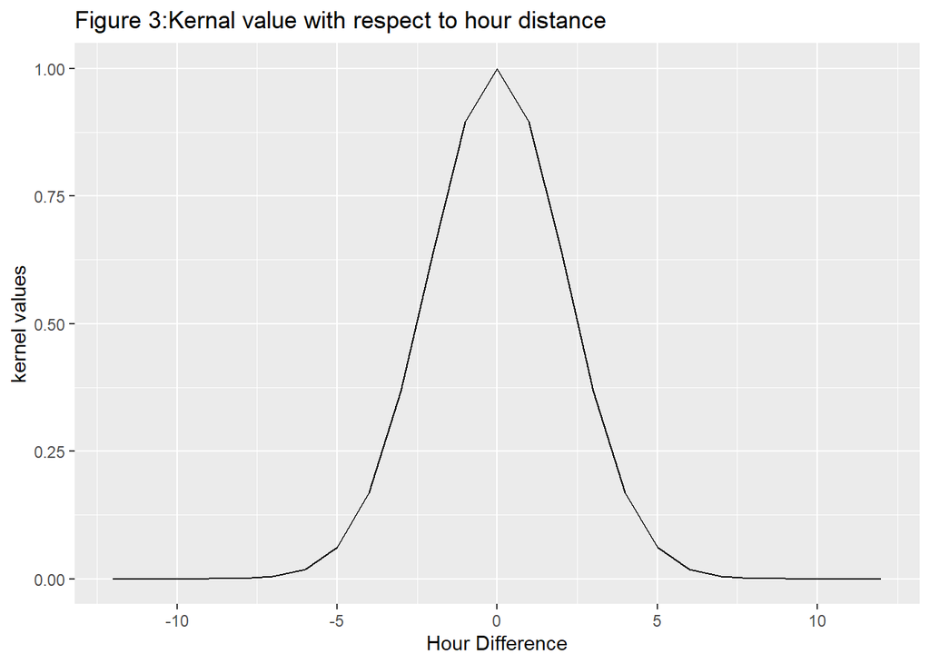

Now, with the kernels width being set. The next step is combining three Guassian kernels by the sum of them and make prediction. Importantly, because the data includes measurements that are posterior to the day and hour of the target time. Filtering must be done before prediction being made.

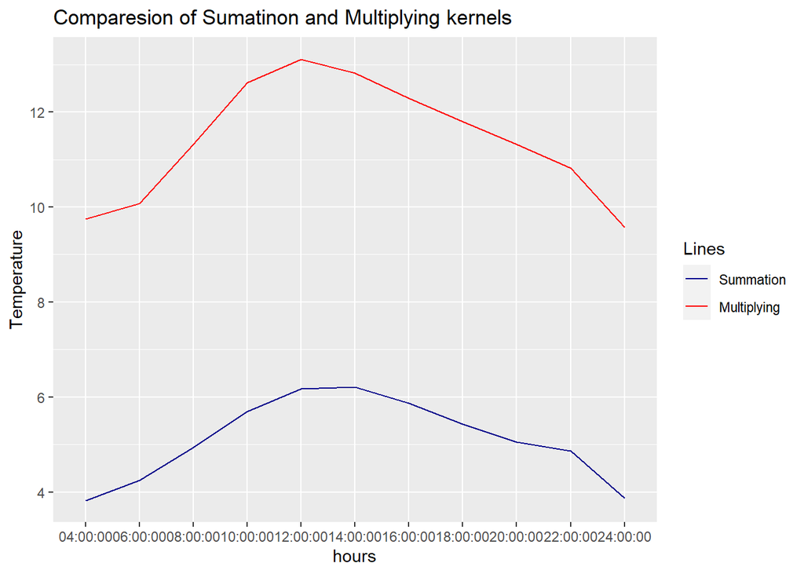